# DAKD 2023 EXERCISE 1: DATA UNDERSTANDING

# START OF EXERCISES

## 1. Introduction to the dataset

The dataset in this exercice contains comprehensive health information from hospital patients with and without cardiovascular disease. The target variable "cardio," reflects the presence or absence of the disease, which is characterized by a buildup of fatty deposits inside the arteries (blood vessels) of the heart.

As is often the case with data analysis projects, the features/variables have been retrieved from different sources:

- doctors notes (texts)
- examination variables that have come from a database containing lab results or taken during a doctors examination
- self reported variables

The exercise data has the following columns/attributes:

[output not shown]

#### *Reading data*

It is good practice to read the features in using their correct types instead of fixing them later. Below, there is ready-made code for you to read in the data, using the data types and column names listed in the above table. Don't change the name of the variable, *data*. It is important in later exercises (for example in ex. 5e) that this is the name of the variable. If you have the dataset in the same folder as this notebook, the path already given to you should work.

```python
 # --- READ IN DATA (no need to change) --------
data_path = "CardioCare_ex1.csv" #if you just give the name of the file it will look for the data in the same folder as your script
data = pd.read_csv(data_path, dtype = {'age': 'int', 'height': 'int', 'body_mass':'int', 'blood_pressure_low':'int', 'blood_pressure_high':'int', 'gender': 'boolean', 'smoke': 'boolean',
       'active':'boolean', 'cardio':'boolean', 'serum_lipid_level':'category', 'family_history':'boolean'}) #the main data you use in this exercise should have this variable name, so that code given for you further on will run.
```

*Exercise 1 a)*

1. First, print out the first five rows of the data.
2. Then, save the feature names to lists by their types: make three lists named **numeric_features**, **binary_features** and **categorical_features**, containing the **names** of the features of each corresponding type (*you can think in terms of this exercise that binary variables can also be called booleans*).

*When working with DataFrames, it can be incredibly helpful to organize column names into a list or lists. This organization simplifies data manipulation and analysis, and can be used to easily select, filter, or perform operations on specific sets of columns, it also prevents typing errors and avoids repetition!*

_For example, you can access all columns in you DataFrame with numeric features using the data[numeric*features] notation*

```python
# --- Your code here for 1 a) ---
```

First, lets print out the first five rows of the data.

```python
data.head(5)
```

|  | age | gender | height | body_mass | blood_pressure_high | blood_pressure_low | smoke | active | cardio | serum_lipid_level | family_history |
| --- | --- | --- | --- | --- | --- | --- | --- | --- | --- | --- | --- |
| 0 | 19797 | False | 161 | 55 | 102 | 68 | False | True | False | elevated | False |
| 1 | 22571 | True | 178 | 68 | 120 | 70 | False | False | False | normal | False |
| 2 | 16621 | True | 169 | 69 | 120 | 80 | False | True | False | normal | False |
| 3 | 16688 | False | 156 | 77 | 120 | 80 | False | True | False | normal | False |
| 4 | 19498 | True | 170 | 98 | 130 | 80 | True | True | True | elevated | False |

Then we save the feature names to lists by their types: make three lists named numeric_features, binary_features and categorical_features, containing the names of the features of each corresponding type

```python
numeric_features=data.select_dtypes(include='int32').columns.tolist()
binary_features=data.select_dtypes(include='bool').columns.tolist()
categorical_features=data.select_dtypes(include='category').columns.tolist()
```

Lets visualize the top 3 rows for the numeric, binary and categorical features

```python
data[numeric_features].head(3)
```

|  | age | height | body_mass | blood_pressure_high | blood_pressure_low |
| --- | --- | --- | --- | --- | --- |
| 0 | 19797 | 161 | 55 | 102 | 68 |
| 1 | 22571 | 178 | 68 | 120 | 70 |
| 2 | 16621 | 169 | 69 | 120 | 80 |

```python
data[binary_features].head(3)
```

|  | gender | smoke | active | cardio | family_history |
| --- | --- | --- | --- | --- | --- |
| 0 | False | False | True | False | False |
| 1 | True | False | False | False | False |
| 2 | True | False | True | False | False |

```python
data[categorical_features].head(3)
```

|  | serum_lipid_level |
| --- | --- |
| 0 | elevated |
| 1 | normal |
| 2 | normal |

## 2. Checking data quality

Often in data analysis projects the data has not been gathered exclusively for the data analysis only but originally for other reasons. Because of this, the features are most often not nicely formatted and may have mistakes. It might be tempting to just use the data as is with a model, but it is very important to first check the data for possible mistakes as they can make all the conclusions you make based on your analysis misleading. One good routine for checking data quality is to first calculate statistical descriptives and then to plot the features to check if the values are realistic.

Some descriptive statistics don't really make sense for certain kinds of features. In pandas, like in many other packages, some functions work differently depending on the data type of a column. In the following exercise we will look at the data descriptive statistics as well as how the behavior can change when the data types are different.

*2 a)* Print out the data types of your dataset below.

_Perhaps the most common data types in pandas (see https://pandas.pydata.org/docs/user_guide/basics.html#basics-dtypes) are **float**, **int**, **bool** and **category**._

Then let's print out the data types of our dataset below. We can see that the data types have been changed according to the documentation.

```python
# --- 2 a) Print the feature types of your dataset --- #
data.dtypes
```

```
age                       int32
gender                  boolean
height                    int32
body_mass                 int32
blood_pressure_high       int32
blood_pressure_low        int32
smoke                   boolean
active                  boolean
cardio                  boolean
serum_lipid_level      category
family_history          boolean
dtype: object
```

*2 b)* Use the **DataFrame.describe() method** in the cell below on your data.

Then we used describe function to analyze descriptive statistics and useful information about our data such as its count, mean, standard deviation, minimum value, maximum value and different quartiles(25%, 50%, 75%) for different numerical variables in our data.

```python
# --- Your code for 2 b) --- #
data.describe()
```

|  | age | height | body_mass | blood_pressure_high | blood_pressure_low |
| --- | --- | --- | --- | --- | --- |
| count | 210.000000 | 210.000000 | 210.000000 | 210.000000 | 210.000000 |
| mean | 19455.504762 | 164.180952 | 73.895238 | 127.857143 | 81.814286 |
| std | 2429.010199 | 7.534648 | 14.612326 | 17.508947 | 9.947652 |
| min | 14367.000000 | 142.000000 | 45.000000 | 90.000000 | 50.000000 |
| 25% | 17635.750000 | 158.000000 | 64.000000 | 120.000000 | 80.000000 |
| 50% | 19778.000000 | 164.000000 | 70.000000 | 120.000000 | 80.000000 |
| 75% | 21230.500000 | 170.000000 | 81.000000 | 140.000000 | 90.000000 |
| max | 23565.000000 | 195.000000 | 125.000000 | 190.000000 | 120.000000 |

*2 c)* Did you get all of the features statistics or not? What do you think happened?

Your answer for 2 c)

The data for the category characteristics "serum_lipid_level" were not provided. Since the values in this column are not numeric, statistics such as mean, standard deviation, min, max, and so on cannot be computed. Similarly, since binary features only have True or False, 0 or 1 values, mean, standard deviation, min, max, and so on cannot be computed for them either. However, by choosing the category variables and using the describe() method, we can compute things like count, unique values, top, and frequency of the top.

```python
data[categorical_features].describe()
```

|  | serum_lipid_level |
| --- | --- |
| count | 210 |
| unique | 4 |
| top | normal |
| freq | 153 |

*2 d)* Calculate descriptives for the binary (boolean) features and the categorical feature

*tip: in python, same type data structures can in many cases be concatenated using the + operator. If youre using the lists of names you created to subset, you can concatenate the two lists of feature names and use the resulting list to help you subset the dataframe*

```python
# 2 d) Your code here #
```

Then we calculate descriptives for the binary (boolean) features and the categorical feature as follows:

```python
#pd.concat([data[categorical_features], data[binary_features]]).describe(include="all")
data[categorical_features+binary_features].describe(include="all")
```

|  | serum_lipid_level | gender | smoke | active | cardio | family_history |
| --- | --- | --- | --- | --- | --- | --- |
| count | 210 | 210 | 210 | 210 | 210 | 210 |
| unique | 4 | 2 | 2 | 2 | 2 | 2 |
| top | normal | False | False | True | False | False |
| freq | 153 | 129 | 186 | 162 | 105 | 128 |

Now, we will see *what would have happened if the data was read in using default settings* and not giving information about the types of the features (dtypes), giving no arguments to pd.read_csv.

Run the below cell (no need to modify the code) and look at the output of the cell with the wrongly read data. Compare it with the output of the cell where you used the correctly read data to get the descriptives.

```python
# read in the dataset with no arguments
wrongly_read_data = pd.read_csv(data_path)

# calculate descriptives for the data that was wrongly read in.
wrongly_read_data.describe()
```

|  | age | gender | height | body_mass | blood_pressure_high | blood_pressure_low | smoke | active | cardio | family_history |
| --- | --- | --- | --- | --- | --- | --- | --- | --- | --- | --- |
| count | 210.000000 | 210.000000 | 210.000000 | 210.000000 | 210.000000 | 210.000000 | 210.000000 | 210.000000 | 210.000000 | 210.000000 |
| mean | 19455.504762 | 0.385714 | 164.180952 | 73.895238 | 127.857143 | 81.814286 | 0.114286 | 0.771429 | 0.500000 | 0.390476 |
| std | 2429.010199 | 0.487927 | 7.534648 | 14.612326 | 17.508947 | 9.947652 | 0.318918 | 0.420916 | 0.501195 | 0.489023 |
| min | 14367.000000 | 0.000000 | 142.000000 | 45.000000 | 90.000000 | 50.000000 | 0.000000 | 0.000000 | 0.000000 | 0.000000 |
| 25% | 17635.750000 | 0.000000 | 158.000000 | 64.000000 | 120.000000 | 80.000000 | 0.000000 | 1.000000 | 0.000000 | 0.000000 |
| 50% | 19778.000000 | 0.000000 | 164.000000 | 70.000000 | 120.000000 | 80.000000 | 0.000000 | 1.000000 | 0.500000 | 0.000000 |
| 75% | 21230.500000 | 1.000000 | 170.000000 | 81.000000 | 140.000000 | 90.000000 | 0.000000 | 1.000000 | 1.000000 | 1.000000 |
| max | 23565.000000 | 1.000000 | 195.000000 | 125.000000 | 190.000000 | 120.000000 | 1.000000 | 1.000000 | 1.000000 | 1.000000 |

*2 e)* Looking at the above output, can you now say whats wrong with this presentation and why it was important to define the data types?

Your answer for 2 e)

```python
wrongly_read_data.dtypes
```

```
age                     int64
gender                  int64
height                  int64
body_mass               int64
blood_pressure_high     int64
blood_pressure_low      int64
smoke                   int64
active                  int64
cardio                  int64
serum_lipid_level      object
family_history          int64
dtype: object
```

From the description it is apparent that the data pertaining to category variables like "serum_lipid_level" and binary variables like "gender," "smoke," "active," "family_history" and "cardio" are inaccurate and deceptive. The mean, std, min, max, and percentile, for instance, are illogical for these columns because they are generally categorical variables. Since the pandas library treats binary and categorical variables as numeric if not explicitly defined or corrected, it makes calculations on them considering them as numerical variables which is not quite accurate. It is better to characterize categorical and binary features with count, frequency, top, and unique, which are absent from the sample above as they are all treated as numerical. Consequently, to prevent this, it is essential to specify the data types.

## 3. Plotting numeric features

Descriptives don't really give a full or intuitive picture of the distribution of features. Next, we will make use of different plots to check the data quality.

*3 a)* Plot the numeric features as histograms (see tutorial if you need help).

*tip: if you give only one grid-size argument for plt.subplots() like plt.subplots(3) the grid will be one-dimensional and you can index it with only one indexer.*

```python
data[numeric_features].iloc[:,3]
```

```
0      102
1      120
2      120
3      120
4      130
      ...
205    120
206    110
207    100
208    120
209    140
Name: blood_pressure_high, Length: 210, dtype: int32
```

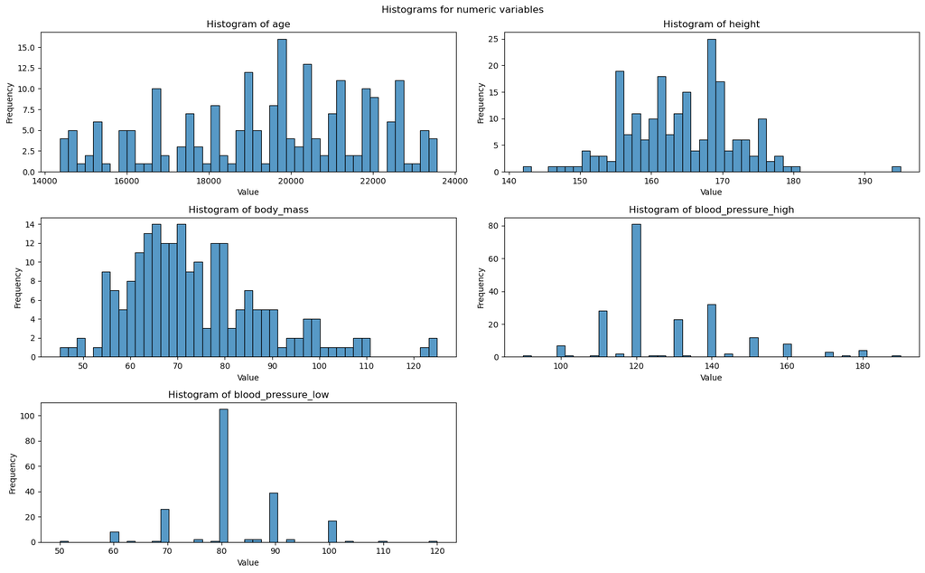

```python
# --- Your code for 3 a) here --- #


fig, axes = plt.subplots(nrows=3, ncols=2, figsize=(16, 10))
fig.delaxes(axes[2,1])
fig.suptitle('Histograms for numeric variables')
numeric_data= data[numeric_features]
for i, col in enumerate(numeric_data):
    row_idx, col_idx = divmod(i, 2)
    ax = axes[row_idx, col_idx]
    #numeric_data[col].histplot(ax=ax, bins=45, fill=False)
    sns.histplot(data=data[col],ax=ax, bins=45)
    ax.set_title(f'Histogram of {col}')
    ax.set_xlabel('Value')
    ax.set_ylabel('Frequency')

plt.tight_layout()
```

## 4. Plotting binary and categorical features

*4 a)* Plot **barplots** for each of the non-numeric features. **Use fractions, not the real frequencies of the levels of these features**.

_tip: For plotting, see documentation on axes.bar. To get the fractions, see the value*counts function and its optional argument normalize.*

*If you read in the dtypes to be pandas dtype.boolean, in some cases its easier to work with other packages, suchs as matplotlib when they are represented as numbers [0,1] and not True or False. If you get errors you can try to cast them momentarily to be int or float with astype. This does not mean that you've done the exercise incorrectly, just that you have to change them for the plotting package.*

```python
### Your code for 4 a) here ###
```

```python
data[categorical_features]
#data[binary_features]
```

|  | serum_lipid_level |
| --- | --- |
| 0 | elevated |
| 1 | normal |
| 2 | normal |
| 3 | normal |
| 4 | elevated |
| ... | ... |
| 205 | normal |
| 206 | normal |
| 207 | normal |
| 208 | normal |
| 209 | normal |

210 rows × 1 columns

[figure not shown]

```python
# --- Your code for a a) here --- #
fig, axes = plt.subplots(2,3, figsize = (10,5))

i = 0 # for indexing to the row of the axes [**i**, j]
j=0  # now axes have indexes like axes[i, j]
for var in (binary_features+categorical_features): # j = [0,1, ... n_datasets] for filling the columns, i stays constant as its the row
    if j==3:
        i=1
        j=0

    values = data[var].value_counts(normalize=True)
    x = data[var].unique().astype(str)
    axes[i, j].bar(x=x,height=values) #plots are called on the axes
    axes[i, j].set_ylim((0,1))
    axes[i, j].set_title(var)

    j=j+1

fig.suptitle('Barplots for binary & categorical variables')
plt.tight_layout()
```

**4 b)** Do you see something odd with one of the features? Fix it.

If you read the dtype of the categorical feature to be pandas dtype.categorical, **you have to also use the pandas function remove_categories to remove the category level from the feature**, even if you would have already removed the value. You can do this like: _data['feature_name'] = data['feature_name'].cat.remove*categories("category name to delete")*

Your answer for 4 b)

```python
### Your code for 4 b) here ###
```

We analyzed if any column had a invalid value. Since the "elev ated" value of the column "serum_lipid_level" is invalid, we fixed it

```python
data["serum_lipid_level"].unique
```

```
<bound method Series.unique of 0      elevated
1        normal
2        normal
3        normal
4      elevated
         ...
205      normal
206      normal
207      normal
208      normal
209      normal
Name: serum_lipid_level, Length: 210, dtype: category
Categories (4, object): ['at risk', 'elev ated', 'elevated', 'normal']>
```

```python
data['serum_lipid_level'] = data['serum_lipid_level'].cat.remove_categories("elev ated")
```

```python
data['serum_lipid_level'].value_counts()
```

```
normal      153
at risk      35
elevated     21
Name: serum_lipid_level, dtype: int64
```

## 5. Feature generation and exploration

Feature Engineering is a crucial step in the process of preparing data for most data analysis projects. It involves creating new features or modifying existing ones to improve the performance of predictive models. Feature engineering is a combination of domain knowledge, creativity, and data analysis, and it can have a significant impact on the success of a data analysis project.

**BMI**, or **Body Mass Index**, is a simple numerical measure that is commonly used to assess an individual's body weight in relation to their height. In our use case, BMI can be a useful indicator in the prediction of cardiovascular problems, as it could provide a well-established link between obesity and an increased risk of developing the disease.

\begin{align*} \text{BMI} & = \frac{\text{Body mass (kg)}}{(\text{height (m)})^2} \\ \end{align*}

*5 a)* Generate a new feature based off of the provided formula, using 'height' and 'body_mass' and name it **BMI**

*tip: In the case of our dataset the height is in centimeters, so make sure to convert it into meters*

```python
### Your code for 5 a) here ###
data["BMI"] = data["body_mass"]/(data["height"]/100)**2
data
```

|  | age | gender | height | body_mass | blood_pressure_high | blood_pressure_low | smoke | active | cardio | serum_lipid_level | family_history | BMI |
| --- | --- | --- | --- | --- | --- | --- | --- | --- | --- | --- | --- | --- |
| 0 | 19797 | False | 161 | 55 | 102 | 68 | False | True | False | elevated | False | 21.218317 |
| 1 | 22571 | True | 178 | 68 | 120 | 70 | False | False | False | normal | False | 21.461937 |
| 2 | 16621 | True | 169 | 69 | 120 | 80 | False | True | False | normal | False | 24.158818 |
| 3 | 16688 | False | 156 | 77 | 120 | 80 | False | True | False | normal | False | 31.640368 |
| 4 | 19498 | True | 170 | 98 | 130 | 80 | True | True | True | elevated | False | 33.910035 |
| ... | ... | ... | ... | ... | ... | ... | ... | ... | ... | ... | ... | ... |
| 205 | 16630 | False | 158 | 55 | 120 | 80 | True | True | False | normal | False | 22.031726 |
| 206 | 16742 | False | 170 | 68 | 110 | 70 | False | True | False | normal | False | 23.529412 |
| 207 | 23117 | False | 157 | 78 | 100 | 60 | False | True | True | normal | False | 31.644286 |
| 208 | 15236 | False | 153 | 55 | 120 | 80 | False | True | False | normal | False | 23.495237 |
| 209 | 18043 | True | 172 | 78 | 140 | 90 | False | False | True | normal | True | 26.365603 |

210 rows × 12 columns

*5 b)* Using the previously calculated feature **BMI** generate a new feature named **BMI_category** that categorizes the values into groups, according to the standard BMI categories :

- Underweight: BMI less than 18.5
- Normal Weight: BMI between 18.5 and 24.9
- Overweight: BMI between 25 and 29.9
- Obese: BMI of 30 or greater

```python
### Your code for 5 b) here ###
data2 = []

for i in range(len(data["BMI"])):

    if (data.loc[i,"BMI"] <18.5) :
        data2.append("Underweight")

    elif((data.loc[i,"BMI"] >= 18.5) & (data.loc[i,"BMI"] <= 24.9)):
        data2.append("Normal Weight")

    elif((data.loc[i,"BMI"] >= 25) & (data.loc[i,"BMI"] <= 29.9)):
        data2.append("Overweight")

    elif (data.loc[i,"BMI"] >= 30) :
        data2.append("Obese")

    else:
        data2.append("Normal Weight")


data["BMI_category"] = pd.DataFrame(data2)
print("Counts for different classes of BMI Category: ")
data["BMI_category"].value_counts()
```

```
Counts for different classes of BMI Category:
```

```
Normal Weight    80
Overweight       72
Obese            56
Underweight       2
Name: BMI_category, dtype: int64
```

Now that we have our BMI values, it's a good practice to see if we can spot a hidden trend in our data.

*5 c)* Create a countplot to visualize the distribution of cardio (target variable) within different BMI categories.

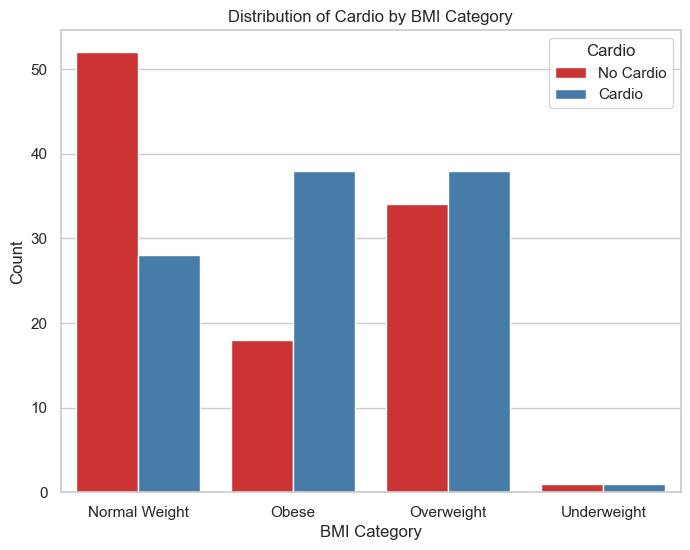

```python
### Your code for 5 c) here ###
# Create a countplot

sns.set(style="whitegrid")
plt.figure(figsize=(8, 6))
sns.countplot(data=data, x="BMI_category", hue="cardio", palette="Set1")

# Set labels and title
plt.xlabel("BMI Category")
plt.ylabel("Count")
plt.title("Distribution of Cardio by BMI Category")

# Show the plot
plt.legend(title="Cardio", labels=["No Cardio", "Cardio"])
plt.show()
```

*5 d)* Can you notice any relationship or visible trend?

Below, there is ready-made code for you to appropriatly add the newly created features to the right column type list. You don't need to change anything about the code, just make sure that the names of the added features are as specified earlier (**BMI** and **BMI_category**)

```python
# ---- Add features to column type list (no need to change) --------
numeric_features.append("BMI")
data['BMI_category'] = data['BMI_category'].astype('category')
categorical_features.append("BMI_category")
```

## 6. Preprocessing numeric features

Scaling the data improves the performance of machine learning algorithms in many cases, or perhaps better put, can ruin performance if not done. For instance with distance based algorithms covered in the course such as PCA, T-SNE and KNN some features with large values can dominate the distance calculations.

We will look at two often used ways of bringing the values to the same scale: **min-max scaling to [0,1]** and **standardizing the features to 0 mean and unit variance**. We will see, that the decision has implications on how the data will look afterwards. Standardizing values is very common in statistics and min-max scaling is for example used in training neural networks, where we want the range to match the range of an activation function in the network. Its good to know both.

Two functions, sklearn.minmax_scale and sklearn.scale have been imported for you and you can use them in the following exercises.

**6 a)** Min-max numeric attributes to [0,1] and **store the results in a new dataframe called data_min_maxed**. You might have to wrap the data to a dataframe again using pd.DataFrame()

The MinMax Scaler reduces the data to fit the specified range, which is typically between 0 and 1. Scaling characteristics to a certain range is how it converts data. Without altering the original distribution's form, it scales the values to a predetermined value range. For this we use the minmax_scale library in which we pass in the numeric features. The results are stored in a new dataframe called data_min_maxed

```python
# --- Your code for 6 a) here --- #
data_min_maxed=pd.DataFrame(minmax_scale(data[numeric_features], feature_range=(0,1)), columns=numeric_features)
data_min_maxed.head(3)
#data_min_maxed.describe()
```

|  | age | height | body_mass | blood_pressure_high | blood_pressure_low | BMI |
| --- | --- | --- | --- | --- | --- | --- |
| 0 | 0.590346 | 0.358491 | 0.1250 | 0.12 | 0.257143 | 0.094180 |
| 1 | 0.891933 | 0.679245 | 0.2875 | 0.30 | 0.285714 | 0.101828 |
| 2 | 0.245053 | 0.509434 | 0.3000 | 0.30 | 0.428571 | 0.186493 |

**6 b)** Standardize numeric attributes to 0 mean and unit variance and **store the results in a new dataframe called data_standardized**

A feature is standardized by StandardScaler by scaling to unit variance after the mean is subtracted. Dividing all the data by the standard deviation yields the unit variance. We do this using StandardScaler and results are stored in the dataframe data_standardized.

```python
# Your code for 6 b here --- #

standardscaler = StandardScaler()
print(standardscaler.fit(data[numeric_features]))

data_standardized = pd.DataFrame(standardscaler.transform(data[numeric_features]), columns=numeric_features)
#data_standardized.describe()
data_standardized.head(3)
```

```
StandardScaler()
```

|  | age | height | body_mass | blood_pressure_high | blood_pressure_low | BMI |
| --- | --- | --- | --- | --- | --- | --- |
| 0 | 0.140926 | -0.423185 | -1.296193 | -1.480325 | -1.392016 | -1.156430 |
| 1 | 1.285684 | 1.838449 | -0.404407 | -0.449822 | -1.190484 | -1.111208 |
| 2 | -1.169727 | 0.641113 | -0.335808 | -0.449822 | -0.182819 | -0.610599 |

**6 c)** Make two boxplots of the 'age' feature, one plot with the data_min_maxed and one with the data_standardized. Preferably put the plots side-by-side and give each titles. See the tutorial in the beginning for help.

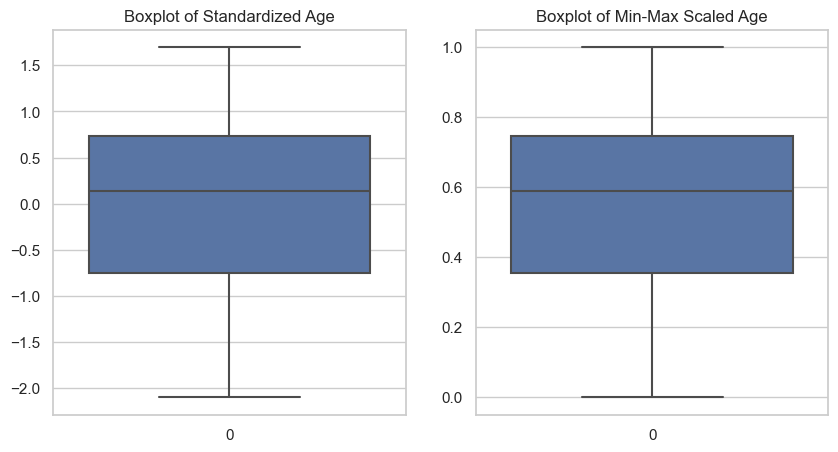

```python
# Create a figure with two subplots
fig, (ax1, ax2) = plt.subplots(1, 2, figsize=(10, 5))

# Create a boxplot for the standardized data
sns.boxplot(data=data_standardized["age"], ax=ax1)
ax1.set_title('Boxplot of Standardized Age')

# Create a boxplot for the min-max scaled data
sns.boxplot(data=data_min_maxed["age"], ax=ax2)
ax2.set_title('Boxplot of Min-Max Scaled Age')

# Show the plots
plt.show()
```

**6 d)** Describe what you would expect to see in these two boxplots. How would the characteristics of the boxplots differ for min-max scaled data and standardized data?

*tip: Consider factors like the location of the mean, and the range of values presented.*

Your answer for 6 d)

For the Min-max scaled data, the range of values is 0 to 1. The Median (Q2/50th percentile) is almost at 0.588, whereas the First Quartile (Q1/25th percentile) could be around 0.355 and Third Quartile (Q3/75th percentile) is 0.746. The mean is 0.55. This differs between the two as the range, values of all the quartiles and also the means and medians are different.

For the Scandardized scaled data, the range of values starts from a point a little below -2 (-2.10e+00) and ends up to more than 1.5 (1.696e+00). The Median (Q2/50th percentile) is at 1.33e-01(0.133), whereas the First Quartile (Q1/25th percentile) could be around -7.51e-01(-0.751) and Third Quartile (Q3/75th percentile) is 7.33e-01(0.733). The mean is 2.96e-17.

```python
#data_standardized["age"].describe()
```

Lets see the differences of these preprocessing methods through an example. We will add an "outlier" point (some point with a large value) to replace the last value in both data, then again minmax and standardize and plot. The code to add the value is given for you and you shouldn't change it.

*6e) Do the following:*

1. Take the data for the age feature (age_w_outlier) provided for you
2. Make two variables, age_w_outlier_minmaxed, containing the min-maxed values of the age_w_outlier and
3. age_w_outlier_standardized containing the standardized values for the age_w_outlier

```python
### Add an outlier, DONT CHANGE THIS CELL CODE, JUST RUN IT ###
data_w_outlier = data.copy() #data should be the name of the variable where you have stored your data!
data_w_outlier.loc[data.shape[0] -1 , 'age'] = 150 #change the last value of age to be 150
age_w_outlier = data_w_outlier.age
age_w_outlier
```

```
0      19797
1      22571
2      16621
3      16688
4      19498
       ...
205    16630
206    16742
207    23117
208    15236
209      150
Name: age, Length: 210, dtype: int32
```

```python
# --- Your code for 6 e) ---

age_w_outlier_minmaxed=minmax_scale(age_w_outlier, feature_range=(0,1))
age_w_outlier_standardized = standardscaler.fit_transform(age_w_outlier.values.reshape(-1,1))
age_w_outlier_standardized=pd.DataFrame(age_w_outlier_standardized)[0]
age_w_outlier_standardized
```

```
0      0.154476
1      1.158731
2     -0.995313
3     -0.971057
4      0.046230
         ...
205   -0.992055
206   -0.951508
207    1.356396
208   -1.496716
209   -6.958212
Name: 0, Length: 210, dtype: float64
```

*Below there is pre-written code for you to plot the different cases. Run it. The code should run if you have named your features appropriately. Run the code.*

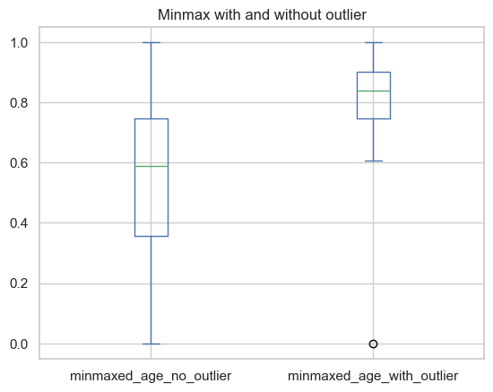

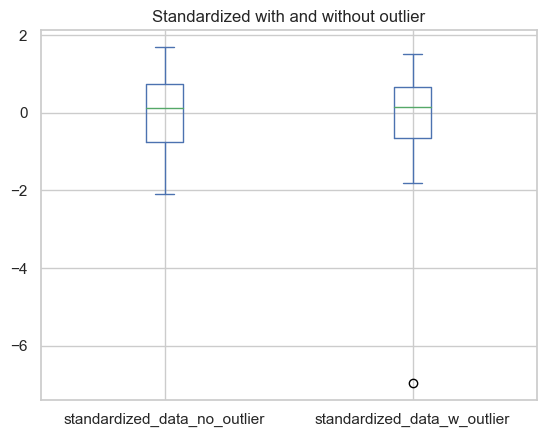

```python
# Wrap in a dataframe that will have two features - the age feature without the outlier, and the age feature with it, min-maxed.
minmaxed_datas = pd.DataFrame({"minmaxed_age_no_outlier" : data_min_maxed.age,
              "minmaxed_age_with_outlier": age_w_outlier_minmaxed })

# Wrap in a dataframe that will have two features - the age feature without the outlier, and the age feature with it, standardized.
standardized_datas = pd.DataFrame({"standardized_data_no_outlier" : data_standardized.age,
              "standardized_data_w_outlier": age_w_outlier_standardized })

axes_minmaxed = minmaxed_datas[['minmaxed_age_no_outlier', 'minmaxed_age_with_outlier']].plot(kind='box', title='Minmax with and without outlier')
axes_std = standardized_datas[['standardized_data_no_outlier', 'standardized_data_w_outlier']].plot(kind='box', title='Standardized with and without outlier')
```

**6 f) Look at the output of the above cell and answer the following**:

1. Can you notice a difference between the two cases (min-maxed and standardized)?
2. Can you say something about the difference of the effect of min-maxing and standardization?

Your answer for 6 f)

1. Compared to Standardization, it is evident that MinMaxScaler is more susceptible to outliers. Based on the boxplots, it appears that the lone outlier has an impact on all of the boxplot variables (as previously noted). Conversely, standardized data appears to be rather resistant to the outlier. The reason, in my opinion, is that the minmax formula, which reads X = (X - Xmin) / (Xmax - Xmin), gives higher weight to the values of min and max than to X. In contrast, standardization is determined using X = (X - mean(values)) / standard_deviation, such that outliers have less of an impact.
2. MinMaxScaler sets the features' scale to a predetermined range, say between 0 and 1, such that 0 is the least value and 1 is the highest. Conversely, StandarScaler forces the features to follow a conventional normal distribution. This results in a feature mean of 0 and a standard deviation of 1. A single outlier—a value that deviates significantly from the average—can have a detrimental effect on the outcomes of minmax, which aims to maintain all values within the range of [0,1]. Since only one or two values that are drastically different from the rest effect the computations, standardizing makes the data more resistant to outliers by using the mean and standard deviation to determine the results.

## 7. Preprocessing categorical features

We can roughly divide categorical variables/features to two types: *nominal categorical* and *ordinal categorical* variables/features. Some cases are clear in terms of which of the two a feature falls into. For example nationality is not an ordered feature, but which grade in school someone is has a natural ordering. **One-hot encoding** was presented in the lectures and will be used in the following exercises with different learning methods.

*Nominal categorical features need to be encoded*, because not encoding them implies that they have an order. For example, consider a dataset where you would have rows by different countries, encoded randomly with numbers, for ex. Finland = 1, Norway = 2 and so on. For some analyses and methods this would imply that Norway is somehow "greater" in value than Finland. For some algorithms, the implication would also be, that some of the countries would be "closer" to each other.

*Ordinal categorical features do not necessarily need to be encoded*, but there are cases where it can be wise. One case is that the categories are not even distance from each other, which is the case with the 'serum_lipid_level' feature with the levels 'normal', 'elevated' and 'at risk'. Its not clear that these are equal in distance from each other. When unsure, it may also be better to one-hot encode, and a lot of packages do it for you behind the scenes. Here we decide to one-hot encode.

*7 a)* One-hot-encode the serum_lipid_level-feature and add the one-hot features to the data. Give the new features meaningful names. Print the first rows of the resulting dataframe.

*tip: pandas has a function for this, google!*

```python
data["serum_lipid_level"].value_counts()
```

```
normal      153
at risk      35
elevated     21
Name: serum_lipid_level, dtype: int64
```

By using the get_dummies function from pandas, wet ransform a category variable into an indicator or dummy variable.

As many 0/1 variables as there are distinct values for each variable are transformed. Each column in the output is named after a value; in the case of a DataFrame input, the value is preceded by the name of the original variable. We store one-hot-encoded features along with the original data in df_encoded.

```python
# --- Your code for 7 a) here ---

df_encoded = pd.get_dummies(data, columns=['serum_lipid_level', ])
df_encoded.head()
```

|  | age | gender | height | body_mass | blood_pressure_high | blood_pressure_low | smoke | active | cardio | family_history | BMI | BMI_category | serum_lipid_level_at risk | serum_lipid_level_elevated | serum_lipid_level_normal |
| --- | --- | --- | --- | --- | --- | --- | --- | --- | --- | --- | --- | --- | --- | --- | --- |
| 0 | 19797 | False | 161 | 55 | 102 | 68 | False | True | False | False | 21.218317 | Normal Weight | 0 | 1 | 0 |
| 1 | 22571 | True | 178 | 68 | 120 | 70 | False | False | False | False | 21.461937 | Normal Weight | 0 | 0 | 1 |
| 2 | 16621 | True | 169 | 69 | 120 | 80 | False | True | False | False | 24.158818 | Normal Weight | 0 | 0 | 1 |
| 3 | 16688 | False | 156 | 77 | 120 | 80 | False | True | False | False | 31.640368 | Obese | 0 | 0 | 1 |
| 4 | 19498 | True | 170 | 98 | 130 | 80 | True | True | True | False | 33.910035 | Obese | 0 | 1 | 0 |

# BONUS EXERCISES

- Below are the bonus exercises. You can stop here, and get the "pass" grade.
- By doing the bonus exercises below, you can get a "pass with honors", which means you will get one point bonus for the exam.

The following exercises are more challenging and not as straight-forward and may require some research of your own. However, perfect written answers are not required, but answers that show that you have tried to understand the problems and explain them with your own words.

## 8. BONUS: Dimensionality reduction and plotting with PCA

In the lectures, PCA was introduced as a dimensionality reduction technique. Here we will use it to reduce the dimensionality of the numeric features of this dataset and use the resulting compressed view of the dataset to plot it. This means you have to, run PCA and then project the data you used to fit the PCA to the new space, where the principal components are the axes.

**8 a)** Do PCA with two components with and without z-score standardization **for the numeric features in the data**.

First we create a PCA model from sklearn and we fit and transform the model with the numeric features, first with normal data and then with standard data and apply the dimensionality reduction on them. Then we specify the number of components to keep after dimensionality reduction as 2 by setting n_components =2

```python
# --- Your for 8 a) code here --- #

# PCA without standardization
pca = PCA(n_components=2)
pca_normal = pca.fit_transform(data[numeric_features])

# PCA with Z-score standardization
pca_standardized = PCA(n_components=2)
pca_std= pca_standardized.fit_transform(data_standardized)
```

**8 b) Plot the data, projected on to the PCA space as a scatterplot, the x-axis being one component and y the other.** Add the total explained variance to your plot as an annotation**. See the documentation of the pca method on how to get the explained variance.

- *Tip: It may be easier to try the seaborn scatterplot for this one. For help see documentation on how to do annotation (see tutorial). The total explained variance is the sum of both the components explained variance*.
- *Tip2*: Depending on how you approach annotating the plot, you might have to cast the feature name to be a string. One nice way to format values in python is the f - formatting string, which allows you to insert expressions inside strings (see example below):

name = Valtteri  
print(f"hello_{name}")

You can also set the number of wanted decimals for floats  
For example f'{float_variable:.2f}' would result in 2 decimals making it to the string created

Then we figure out how much variance is explained for both the normal and standardized cases. We keep the first and second components numbered with 0 and 1 as PC1 and PC2.

```python
# --- Your code for 8 b) --- you can make more cells if you like ---

# Create a DataFrame with the PCA results
pca_df = pd.DataFrame(data=pca_normal, columns=['PC1', 'PC2'])
pca_std_df = pd.DataFrame(data=pca_std, columns=['PC1', 'PC2'])

# Get the explained variance
explained_variance_ratio_normal = pca.explained_variance_ratio_
total_explained_variance_normal = sum(explained_variance_ratio_normal)

explained_variance_ratio_std = pca_standardized.explained_variance_ratio_
total_explained_variance_std = sum(explained_variance_ratio_std)
#total_explained_variance_std
```

```python
pca_std_df
```

|  | PC1 | PC2 |
| --- | --- | --- |
| 0 | -2.572624 | 0.313551 |
| 1 | -1.095064 | 0.129955 |
| 2 | -0.986814 | 0.044130 |
| 3 | -0.100426 | 0.855625 |
| 4 | 1.534066 | 1.414520 |
| ... | ... | ... |
| 205 | -1.803207 | -0.661949 |
| 206 | -1.760311 | 0.804894 |
| 207 | -0.881381 | 2.279017 |
| 208 | -1.834307 | -0.502165 |
| 209 | 0.674517 | -0.641271 |

210 rows × 2 columns

```python
pca_df
```

|  | PC1 | PC2 |
| --- | --- | --- |
| 0 | -341.441127 | -35.554821 |
| 1 | -3115.469507 | -17.939140 |
| 2 | 2834.515284 | -5.154578 |
| 3 | 2767.507526 | -1.661066 |
| 4 | -42.518438 | 11.919816 |
| ... | ... | ... |
| 205 | 2825.528457 | -11.651546 |
| 206 | 2713.533683 | -17.717993 |
| 207 | -3661.451295 | -34.564560 |
| 208 | 4219.526805 | -9.650454 |
| 209 | 1412.481294 | 17.018530 |

210 rows × 2 columns

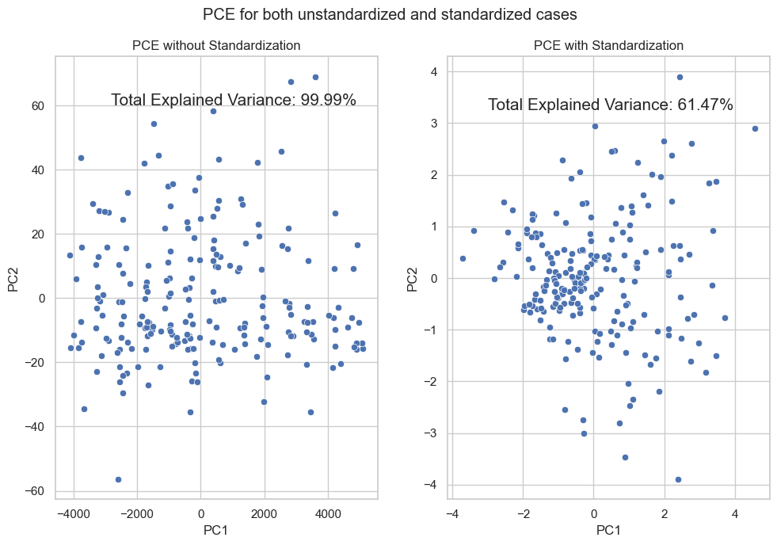

```python
fig, axes = plt.subplots(ncols=2, figsize=(10,7))
sns.scatterplot(data=pca_df,x='PC1', y='PC2', ax=axes[0]).set(title='PCE without Standardization')

sns.scatterplot(data=pca_std_df,x='PC1', y='PC2', ax=axes[1]).set(title='PCE with Standardization')

axes[0].annotate(f'Total Explained Variance: {total_explained_variance_normal:.2%}',
             xy=(-2810, 60.02), fontsize=15)

axes[1].annotate(f'Total Explained Variance: {total_explained_variance_std:.2%}',
             xy=(-3, 3.25), fontsize=15)
fig.suptitle("PCE for both unstandardized and standardized cases")


plt.tight_layout()
```

**8 c) Gather information for the next part of the exercise and print out the following things:**

- First, the standard deviation of the original data features (not standardized, and with the numeric features only).
- Second, the standard deviation of the standardized numeric features

First, we print out the standard deviation of the original data features (not standardized, and with the numeric features only).

```python
# --- Your code for 8 c) here --- #
std_original=data[numeric_features].std()
print("std_original:\n",std_original)
```

```
std_original:
 age                    2429.010199
height                    7.534648
body_mass                14.612326
blood_pressure_high      17.508947
blood_pressure_low        9.947652
BMI                       5.400075
dtype: float64
```

Then we print out the standard deviation of the standardized numeric features

```python
std_standardized=data_standardized.std()
print("std standardized:\n",std_standardized)
```

```
std standardized:
 age                    1.002389
height                 1.002389
body_mass              1.002389
blood_pressure_high    1.002389
blood_pressure_low     1.002389
BMI                    1.002389
dtype: float64
```

**8 d) Look at the output above and the explained variance information you added as annotations to the plots. Try to think about the following questions and give a short answer of what you think has happened:**

1. Where do you think the difference between the amounts of explained variance might come from?
2. Can you say something about why it is important to scale the features for PCA by looking at the evidence youve gathered?

**Answer in your own words, here it is not important to get the perfect answer but to try to think and figure out what has happened**

Your answer for 8 d)

1) Measured statistically, explained variance indicates the extent to which each principle component (eigenvector) produced by the principal component analysis (PCA) technique accounts for the variation in a dataset. Simply expressed, it describes the degree of variation in a data set that each primary component is responsible for. As a result, the variance is also high when the values are unstandardized and simply plain big. Because standard scaler scales the data to have a standard deviation of 1, the difference in the amount of explained variation is caused by standardization The variance of all the various principle components added together makes up the overall variance.

2) In my opinion, data should be scaled since disparate scales may have an impact on one another. To facilitate easy analysis, data with different scales are translated to the same scale by standardization. The elements in PCA that maximize variance are of relevance to us. PCA may conclude that, if those characteristics are not scaled, the direction of greatest variance more closely aligns with the "weight" axis if one component—such as human height—varies less than another—such as weight—due to their different scales (meters vs. kilograms). This is obviously false because it can be argued that a change of one meter in height is far more significant than a change of one kilogram in weight.

## 9. Bonus: t-SNE and high dimensional data

Another method that can be used to plot high-dimensional data introduced in the lectures was t-distributed Stochastic Neighbor Embedding (t-SNE).

*9 a)* Run t-SNE for both standardized and non standardized data (as you did with PCA).

Just like PCA, we create a t-SNE model from sklearn and we fit and transform the model with the numeric features, first with normal data and then with standard data and apply the dimensionality reduction on them. Then we specify the number of components to keep after dimensionality reduction as 2 by setting n_components =2. We keep the first and second components numbered with 0 and 1 as TSNE1 and TSNE2.

```python
# --- Your code for 9 a) here --- #

# Creation of a t-SNE model
target = data['cardio']
tsne_normal = TSNE(n_components=2, random_state=42)

# Fitting and transforming the non-standardized data
df_tsne_normal = pd.DataFrame(tsne_normal.fit_transform(data[numeric_features]), columns=["TSNE1", "TSNE2"])

# Create a t-SNE model
tsne_standardized = TSNE(n_components=2, random_state=42)

# Fitting and transformingthe standardized data
df_tsne_standardized = pd.DataFrame(tsne_standardized.fit_transform(data_standardized[numeric_features]), columns=["TSNE1", "TSNE2"])

df_tsne_normal['cardio'] = data['cardio']
df_tsne_standardized['cardio'] = data['cardio']
```

Now, df_tsne_normal and df_tsne_standardized contains the 2D representation of your standardized data

```python
df_tsne_standardized
```

|  | TSNE1 | TSNE2 | cardio |
| --- | --- | --- | --- |
| 0 | 4.254627 | 11.673664 | False |
| 1 | 6.411007 | -0.323306 | False |
| 2 | 5.795018 | 3.799795 | False |
| 3 | -5.186255 | 6.362766 | False |
| 4 | 3.017860 | -8.655324 | True |
| ... | ... | ... | ... |
| 205 | -0.854307 | 10.866362 | False |
| 206 | 6.923463 | 5.407606 | False |
| 207 | 8.284455 | 9.362206 | True |
| 208 | -1.503003 | 11.986401 | False |
| 209 | 6.279354 | -4.811026 | True |

210 rows × 3 columns

*9 b)* Plot t-sne, similarly to PCA making the color of the points correspond to the levels of the cardio feature, but having only numerical features as a basis of the T-SNE.

```python
df_tsne_normal
```

|  | TSNE1 | TSNE2 | cardio |
| --- | --- | --- | --- |
| 0 | -0.706719 | -0.255708 | False |
| 1 | -18.892450 | 0.377682 | False |
| 2 | 16.133017 | 0.277598 | False |
| 3 | 15.878757 | 0.154822 | False |
| 4 | 0.907527 | 0.074920 | True |
| ... | ... | ... | ... |
| 205 | 16.103765 | 0.233549 | False |
| 206 | 15.660990 | 0.281854 | False |
| 207 | -20.451942 | 0.283430 | True |
| 208 | 19.427504 | 0.497037 | False |
| 209 | 11.279219 | 0.208554 | True |

210 rows × 3 columns

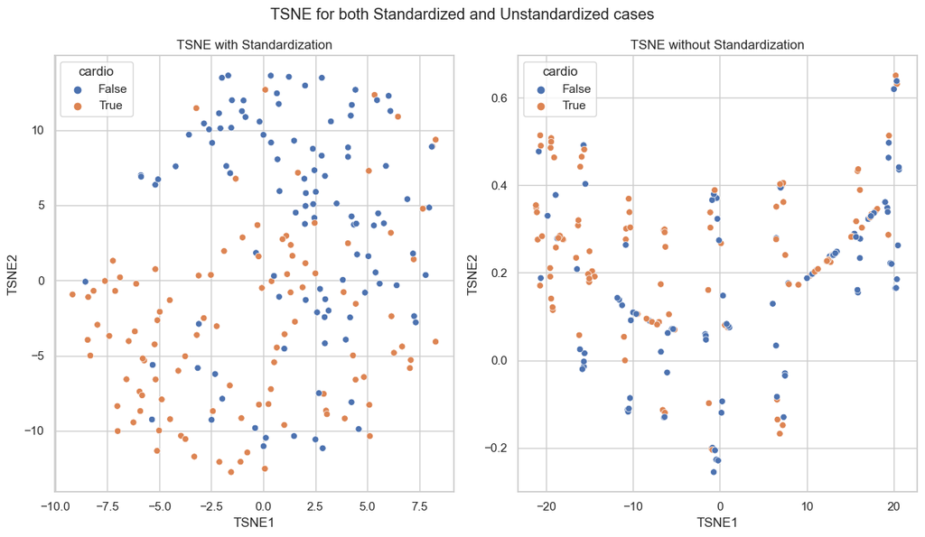

```python
# --- Code for 9 b --- #

fig, axes = plt.subplots(ncols=2, figsize=(12,7))
sns.scatterplot(data=df_tsne_standardized, x="TSNE1", y="TSNE2", ax=axes[0], hue='cardio').set(title='TSNE with Standardization')
sns.scatterplot(data=df_tsne_normal, x="TSNE1", y="TSNE2", ax=axes[1], hue='cardio').set(title='TSNE without Standardization')
fig.suptitle("TSNE for both Standardized and Unstandardized cases")
plt.tight_layout()
```

We keep TSNE1 on x axis and TSNE2 on y axis.

*9 c)*

- What do you think might have happened between the two runs of t-SNE on unstandardized and standardized data? Why is it important to standardize before using the algorithm?

*Here the aim is to think about this and learn, not come up with a perfect explanation. Googling is encouraged. Think about whether t-sne is a distance based algorithm or not?*

Your answer for 9 c)

Since t-SNE generates a probability distribution to describe the similarities between neighbors, scaling is crucial to its operation.Since the t-sne method is based on distance, it is crucial to scale the data such that each characteristic is given the same weight. Like PCA, features with high variation have the potential to impact or change features with low variance. Next, it determines how far apart different points are from one another, which essentially clusters the points according to their distances. The reason the data must now be normalized is that t-SNE will be worthless if the data's standard deviation is not equal to 1 or 2 (I'm not sure if those are the limitations). This is because the distances cannot be appropriately calculated.